# TALLER: UNA GUÍA PRÁCTICA PARA USAR LOS DATOS DEL BARÓMETRO DE LAS AMÉRICAS

Arturo Maldonado - Pontificia Universidad Católica del Perú

22/09/2020

# REPLICACIÓN DEL TOPICAL BRIEF 035

# Tolerancia a los “golpes de Estado” ejecutivos en Perú

# Autoras: Mariana V. Ramírez Bustamante y Elizabeth J. Zechmeister - Vanderbilt University

## ABSTRACT

Para este taller, se asume que los participantes tienen un conocimiento básico de R y RStudio. A lo largo de este taller, explicaremos, paso a paso, los procedimientos en RStudio para producir las tablas y gráficos que se ven en los informes. En estos informes, estas tablas y gráficos han sido producidos originalmente en STATA.

En resumen, este informe presenta el promedio de tolerancia a los “golpes de Estado” ejecutivos en las Américas y la tendencia en el tiempo de esta tolerancia en Perú.

## SOBRE LA BASE DE DATOS

Los datos que vamos a usar deben citarse de la siguiente manera: Fuente: Barómetro de las Américas por el Proyecto de Opinión Pública de América Latina (LAPOP), wwww.LapopSurveys.org.

Pueden descargar los datos de manera libre [aquí](http://datasets.americasbarometer.org/database/login.php)

En este enlace, se puede registrar o entrar como “Free User”. En el buscador, se puede ingresar el texto “merge”. Ahí se tendrá acceso a la base de datos completa “2004-2018 Grand Merge Free” en versión para STATA. Se descarga la base de datos en formato zip, la que se descomprime en formato .dta.

Debido a que estas bases de datos son muy grandes (42MB en formato zip), para este taller vamos a trabajar con una versión reducida, que incluye los países y años seleccionados en el informe. Esta base de datos y todos los materiales para esta taller se pueden descargar [aquí](https://github.com/arturomaldonado/TallerLAPOP2020.git)

## INSTALANDO LOS PAQUETES NECESARIOS EN R

## LEYENDO LA BASE DE DATOS EN R

*Si se trabajara con la base de datos descargada del repositorio de LAPOP*

En este taller vamos a trabajar con una versión simplificada de la base de datos, que incluye solo las variables necesarias para el análisis. Esta base reducida directamente la leemos en RStudio y seleccionamos la ronda de trabajo.

```r
lapop <- import("LAPOP_reduced_merge.dta")
lapop <- subset(lapop, wave==2018)
lapop <- subset(lapop, pais<=23)
```

El análisis para el gráfico 1 incluye a todos los países y el análisis del gráfico 2 incluye todas las rondas para Perú. Al momento de leer la base de datos en R, este programa importa las variables como numéricas. La variable “pais” se tiene que convertir en una variable de tipo “factor” y se tiene que etiquetar.

```r
lapop$pais = as.factor(lapop$pais)
levels(lapop$pais) <- c("México", "Guatemala", "El Salvador", "Honduras",
                        "Nicaragua","Costa Rica", "Panamá", "Colombia",
                        "Ecuador", "Bolivia", "Perú", "Paraguay", "Chile",
                        "Uruguay", "Brasil", "Argentina",
                        "Rep. Dom.", "Jamaica")
table(lapop$pais)
```

```
##
##      México   Guatemala El Salvador    Honduras   Nicaragua  Costa Rica
##        1580        1596        1511        1560        1547        1501
##      Panamá    Colombia     Ecuador     Bolivia        Perú    Paraguay
##        1559        1663        1533        1682        1521        1515
##       Chile     Uruguay      Brasil   Argentina   Rep. Dom.     Jamaica
##        1638        1581        1498        1528        1516        1513
```

## GRÁFICO 1

La autora indica que para este reporte se ha usado la pregunta: JC15A: ¿Cree usted que cuando el país enfrenta momentos muy difíciles, se justifica que el presidente del país cierre el Congreso y gobierne sin Congreso? 1. Sí se justifica 2. No se justifica Esta base de datos ya cuenta con una variable recodificada llamada “jc15ar”, de tal manera que 1=100 y 2=0. Con el siguiente código se calcula la media de esta variable recodificada por cada país, tomando en cuenta la ponderación por país. Estos datos se guardan en un nuevo dataframe “tab.jc15ar”.

```r
tab.jc15ar <- as.data.frame(compmeans(lapop$jc15ar, lapop$pais, lapop$weight1500, plot=FALSE))
tab.jc15ar
```

```
##                  Mean     N Std. Dev.
## México      28.075052  1366  44.95304
## Guatemala   22.797579  1398  41.96771
## El Salvador 18.149965  1417  38.55677
## Honduras    25.657427  1353  43.69039
## Nicaragua   21.698113   719  41.24764
## Costa Rica  17.261056   701  37.81803
## Panamá      25.437416   715  43.58138
## Colombia    16.546763   752  37.18493
## Ecuador     23.956931   727  42.71145
## Bolivia     27.272727   667  44.56960
## Perú        58.923885   751  49.22996
## Paraguay    27.167630   685  44.51489
## Chile       21.279555   658  40.95954
## Uruguay      9.221902   658  28.95548
## Brasil      22.289784   716  41.64814
## Argentina   13.212796   706  33.88700
## Rep. Dom.   24.305061  1388  42.90800
## Jamaica     23.959828   691  42.71475
## Total       23.843688 16069  42.61409
```

En este dataframe, se cambian los nombres de las columnas, se agrega una nueva columna “pais”, se calcula el error estándar y el margen de error y se eliminan la fila de total.

```r
varnames <- c("media", "n", "sd")
colnames(tab.jc15ar) <- varnames
tab.jc15ar$pais <- row.names(tab.jc15ar)
tab.jc15ar$err.st <- tab.jc15ar$sd/sqrt(tab.jc15ar$n)
tab.jc15ar$ci <- tab.jc15ar$err.st*1.96
tab.jc15ar <- tab.jc15ar[-19, ]
tab.jc15ar
```

```
##                 media    n       sd        pais   err.st       ci
## México      28.075052 1366 44.95304      México 1.216280 2.383910
## Guatemala   22.797579 1398 41.96771   Guatemala 1.122436 2.199975
## El Salvador 18.149965 1417 38.55677 El Salvador 1.024273 2.007575
## Honduras    25.657427 1353 43.69039    Honduras 1.187783 2.328054
## Nicaragua   21.698113  719 41.24764   Nicaragua 1.538277 3.015024
## Costa Rica  17.261056  701 37.81803  Costa Rica 1.428367 2.799600
## Panamá      25.437416  715 43.58138      Panamá 1.629851 3.194508
## Colombia    16.546763  752 37.18493    Colombia 1.355995 2.657750
## Ecuador     23.956931  727 42.71145     Ecuador 1.584080 3.104797
## Bolivia     27.272727  667 44.56960     Bolivia 1.725742 3.382454
## Perú        58.923885  751 49.22996        Perú 1.796427 3.520997
## Paraguay    27.167630  685 44.51489    Paraguay 1.700826 3.333620
## Chile       21.279555  658 40.95954       Chile 1.596769 3.129668
## Uruguay      9.221902  658 28.95548     Uruguay 1.128802 2.212452
## Brasil      22.289784  716 41.64814      Brasil 1.556464 3.050669
## Argentina   13.212796  706 33.88700   Argentina 1.275354 2.499694
## Rep. Dom.   24.305061 1388 42.90800   Rep. Dom. 1.151711 2.257354
## Jamaica     23.959828  691 42.71475     Jamaica 1.624946 3.184893
```

Con estos datos en el dataframe se usa el siguiente código para producir el gráfico 1.

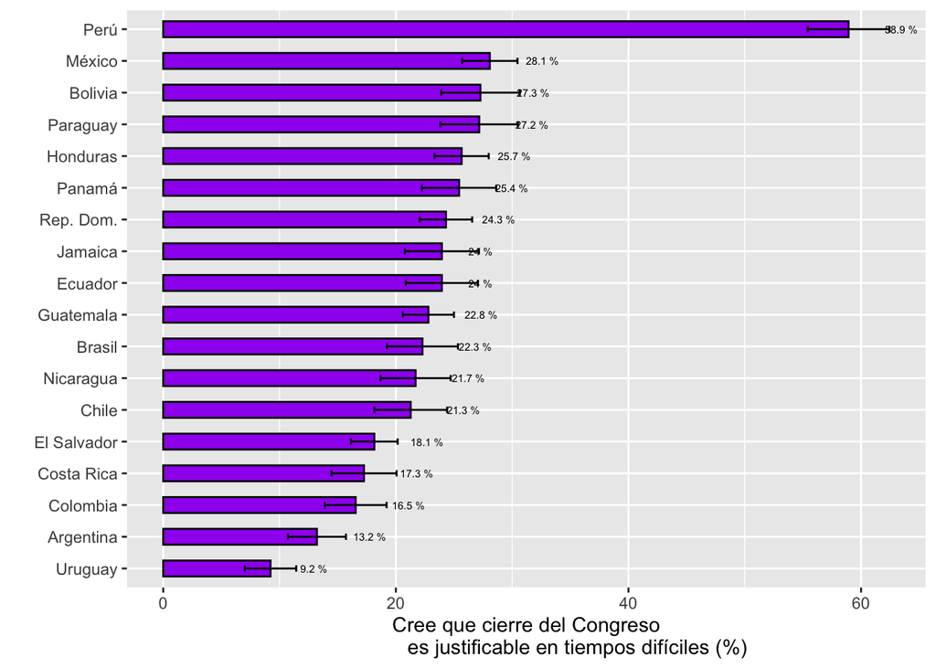

```r
graf035_1 <- ggplot(tab.jc15ar, aes(x=reorder(pais, media), y=media)) +
  geom_bar(width=0.5, fill="purple", colour="black", stat="identity")+
  geom_errorbar(aes(ymin=media-ci, ymax=media+ci), width=0.2)+
  geom_text(aes(label=paste(round(media, 1), "%")), hjust=-1.1, size=2)+
  xlab("") + ylab("Cree que cierre del Congreso
                  es justificable en tiempos difíciles (%)")+
  coord_flip()
graf035_1
```

## GRÁFICO 2

Para producir el gráfico 2 se va a trabajar con la base de datos de Perú para todas las rondas. La base de datos con la que se trabajará en este taller es una reducida, que solo incluye las variables necesarias para este análisis.

```r
peru <- import("Peru reduced.dta")
```

Con este dataframe se calcula el promedio de la variable “jc15ar” por año y se guarda en un nuevo dataframe “tab.peru”.

```r
tab.peru <- as.data.frame(compmeans(peru$jc15ar, peru$year, peru$weight1500, plot=FALSE))
tab.peru
```

```
##           Mean    N Std. Dev.
## 2010  26.45390 1410  44.12439
## 2012  21.98839 1378  41.43182
## 2014  27.38351 1395  44.60853
## 2017  37.82106 1446  48.51083
## 2019  58.92388  751  49.22996
## Total 32.09307 6380  46.68708
```

De la misma manera que en el gráfico 1, se tiene que adecuar este dataframe para tener los datos por año necesarios para producir el gráfico 2.

```r
colnames(tab.peru) <- varnames
tab.peru$year <- row.names(tab.peru)
tab.peru$err.st <- tab.peru$sd/sqrt(tab.peru$n)
tab.peru$ci <- tab.peru$err.st*1.96
tab.peru <- tab.peru[-6, ]
tab.peru
```

```
##         media    n       sd year   err.st       ci
## 2010 26.45390 1410 44.12439 2010 1.175085 2.303166
## 2012 21.98839 1378 41.43182 2012 1.116116 2.187587
## 2014 27.38351 1395 44.60853 2014 1.194348 2.340922
## 2017 37.82106 1446 48.51083 2017 1.275718 2.500407
## 2019 58.92388  751 49.22996 2019 1.796427 3.520997
```

Primero se crea el gráfico de líneas que muestra el cambio en el promedio de esta variable por año para Perú.

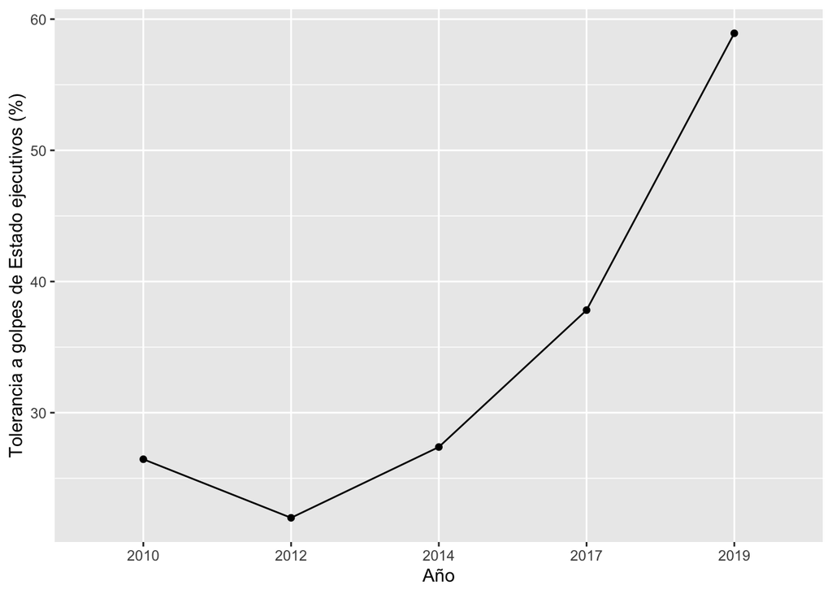

```r
graf2 <- ggplot(tab.peru, aes(x=year, y=media, group=1)) +
  geom_line() +
  geom_point() +
  ylab("Tolerancia a golpes de Estado ejecutivos (%)") +
  xlab("Año")
graf2
```

A este gráfico se le agrega la franja con el intervalo de confianza.

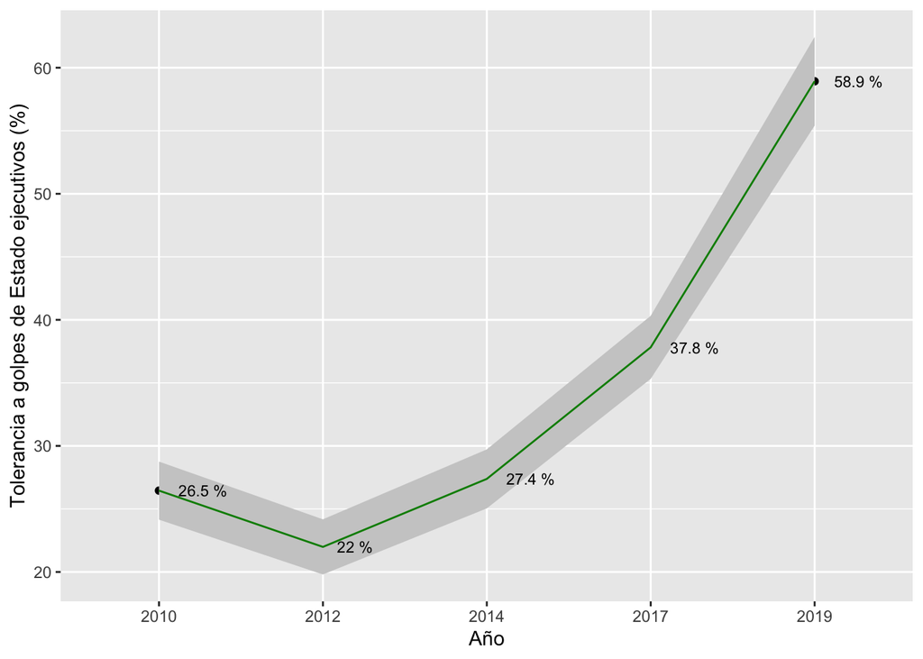

```r
graf035_2 <- graf2 + geom_ribbon(aes(ymin=media-ci,
                             ymax=media+ci),
                            linetype=1,
                            fill="grey80", outline.type="upper") +
            geom_line(aes(y=media), colour="green4") +
            geom_text(aes(label=paste(round(media, 1), "%")),
                      hjust=-0.4, size=3)
graf035_2
```

De esta manera se han replicado los gráficos presentados en este Brief 035 de la Serie Perspectivas usando los datos del Barómetro de las Américas por LAPOP.

[figure not shown]

[figure not shown]

[figure not shown]